# 1 Probability

### 1.1 Probability

Probability theory underlies the statistical hypothesis.

### 1.2 Terminology

Events are the number of possible outcome of a phenomenon such as the roll of a die or a fillip of a coin.

“trials” are a coin flip or die roll

### 1.3 Total Number of Outcomes

We are interested in the probability of something happening relative to the total number of possible outcomes.

Consider tossing a coin together with throwing a die.

Two possible outcomes of the coin flip

Six possible outcomes of the die toss

Without regard for order, what are the total number of outcomes of the two events together?

H1, H2, H3 .

Number of events for each trial

k1 = 2, k2 = 6

So, in general:

- The number of events = k1 x k1 x k3 x kn

### 1.4 Probability

Most probability exercises focus on set notation.

Simple understanding creates the foundation for advanced topics.

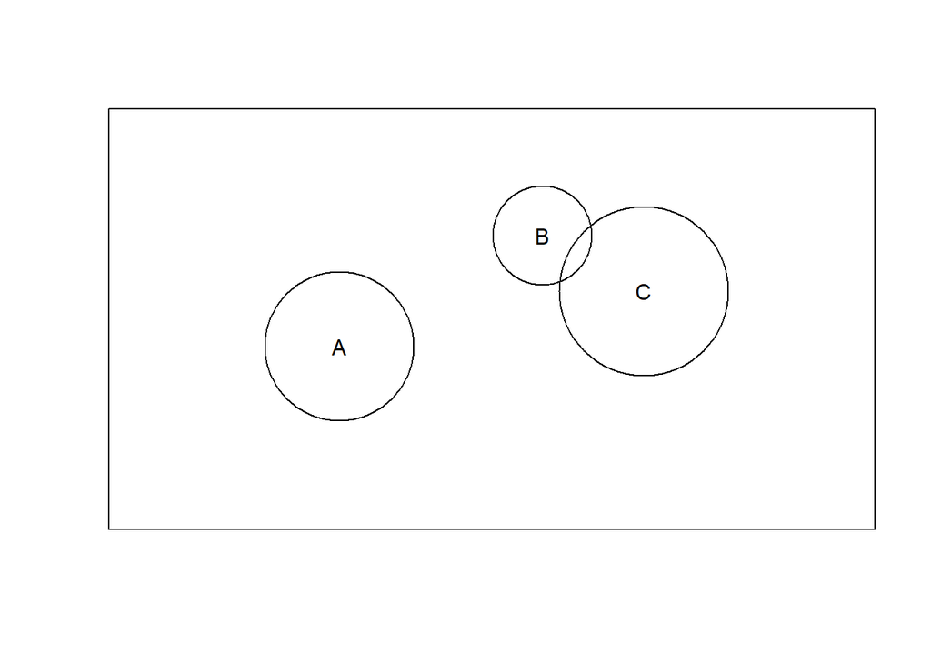

*Figure 1.4.1*

### 1.5 Venn Diagram

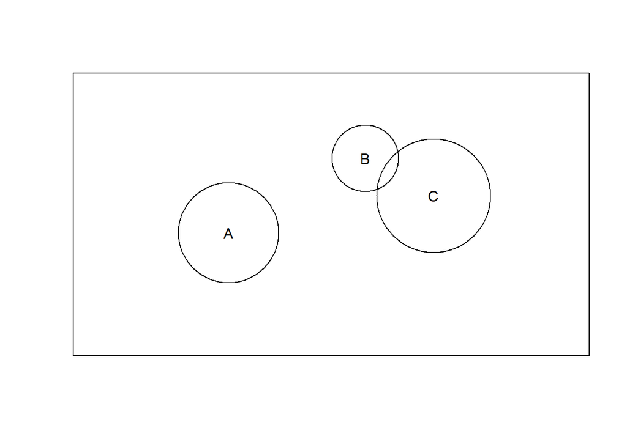

*Figure 1.5.1*

In any experiment there is a set of possible outcomes “outcome set”

Intersect - the common elements in two sets

Mutually exclusive - sets with no elements in common, null intersect

Union - the combination of elements in two sets.

Complement - the remainder of outcomes in a set that are not in a subset

- Ex: if a set is defined as “even numbered die rolls” the complement are those rolls that are “odd numbered”

### 1.6 Probability of an Event

Define the relative frequency:

- N is the total number of events
- f is the number of times that outcomes in the subset were observed.

$\mbox{relative frequency of an event}=\frac{\mbox{frequency of that event}}{\mbox{total number of all events}}=\frac{f}{n}$

### 1.7 Some notation

Note on notation:

- Trial<sub>1</sub> the subscript is for the trial

P(Trial<sub>1</sub> = 1) = 1/6 P(Trial<sub>1</sub> = “H”) = 0.5 So if we have three trials:

- P(Trial<sub>1</sub> = “H”), P(Trial<sub>2</sub>= “H”), P(Trial<sub>3</sub>= “T”)

### 1.8 Mutually Exclusive Events

If two events are mutually exclusive “A” and “B” then the probability of either event is the sum of the probabilities:

P(A or B) = P(A) + P(B)

P(“HRC win” or “DJT win”) = P(“HRC win”) + “DJT win”

These are disjoint sets - both outcomes cannot be realized.

### 1.9 Non-Mutually Exclusive Events

If events are not mutually exclusive:

- i.e.. both outcomes can be realized

Sets “Mammals” and “flying vertebrates” are not disjoint.

P(A or B) = P(A) + P(B) - P(A and B)

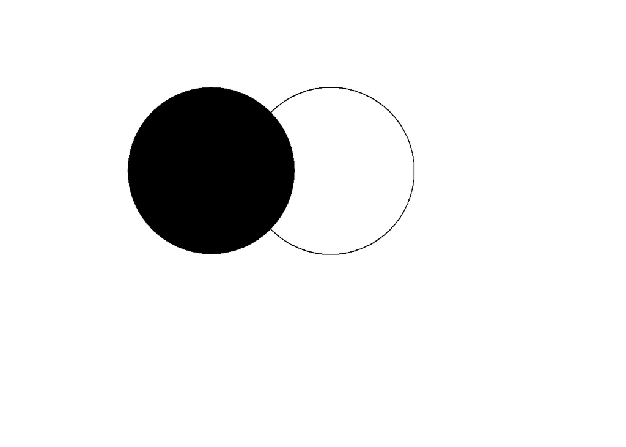

*Figure 1.9.1*

### 1.10 Example 1

Probability of non-mutually exclusive events

- P(A or B) = P(A) + P(B) - P(A and B)

Using a single die:

P(“odd number” or “number < 4”)

P(“odd number”) = P(1) + P(3) + P(5) = ?

P(“number < 4”) = P(1) + P(2) + P(3) = ?

P(“odd number” and “number < 4”) = P(1) + P(3) = 1/3

### 1.11 Probability of Events

Mutually exclusive:

- P(A or B) = P(A) + P(B)

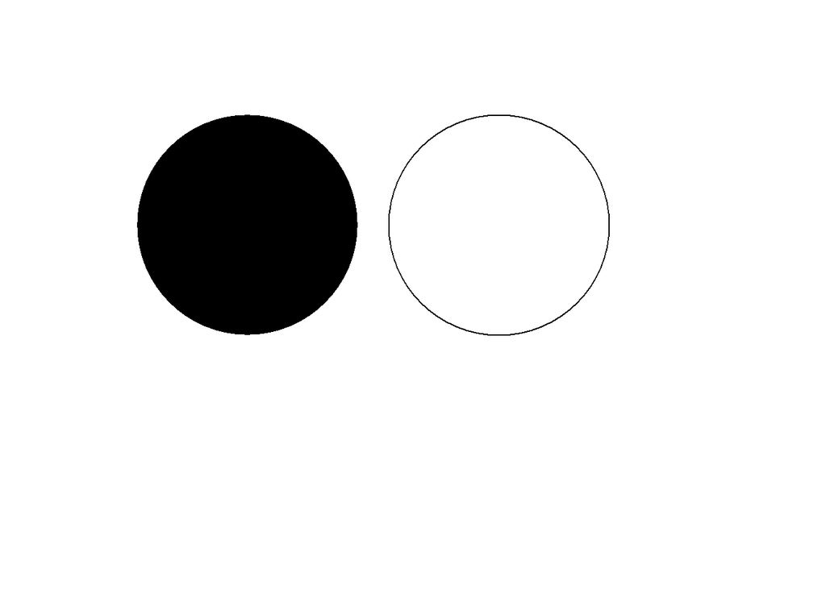

*Figure 1.11.1*

Non-mutually exclusive:

- P(A or B) = P(A) + P(B) - P(A and B)

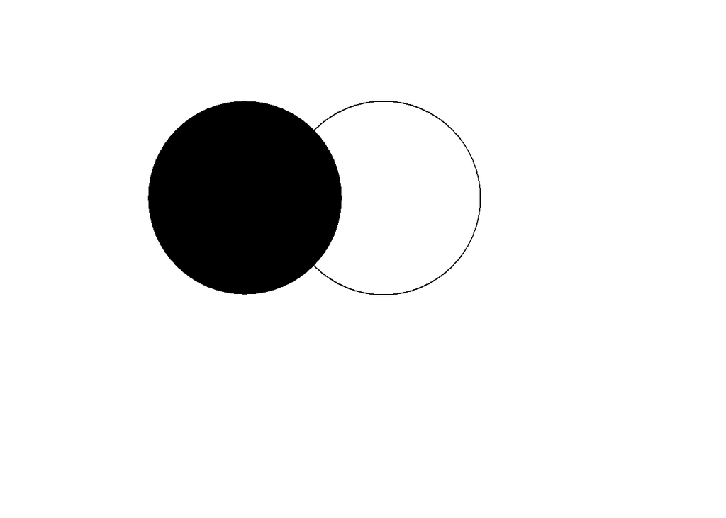

*Figure 1.11.2*

### 1.12 Example 2: P(A or B) = P(A) + P(B) - P(A and B)

Deck of cards

13 in each suit (4 suits)

Cards in each suit: 2 to 10, J, Q, K, A

P(“Diamond”) =

P(“King”) =

P(“Diamond” or “King”) =

### 1.13 Non-Mutually Exclusive Events

P(A or B or C) =

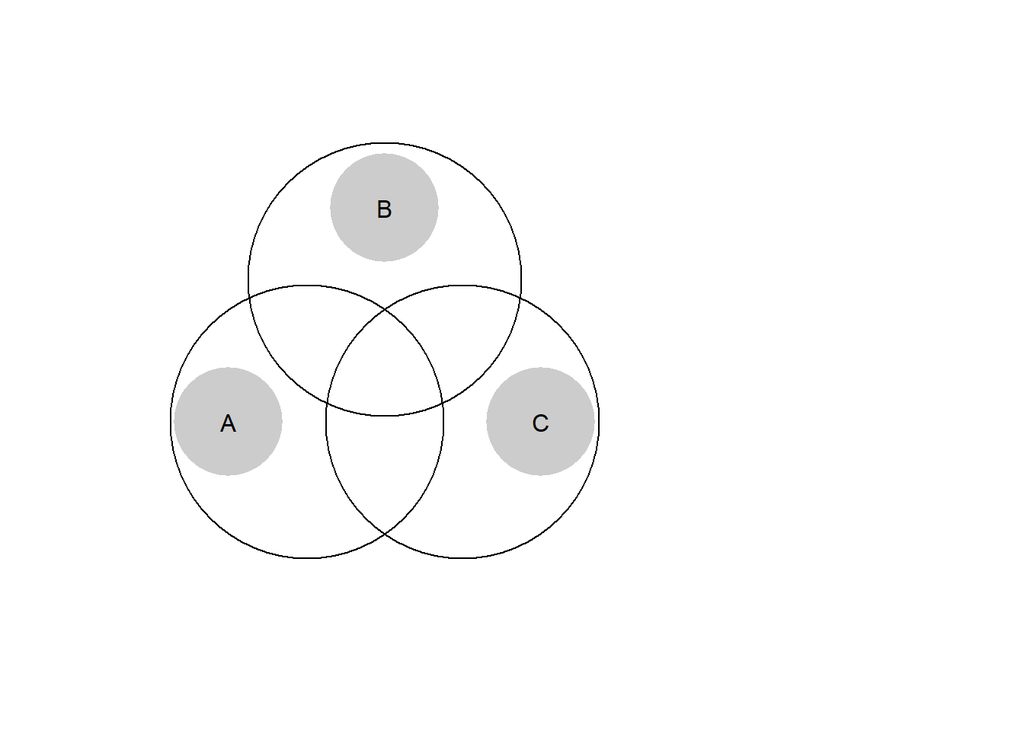

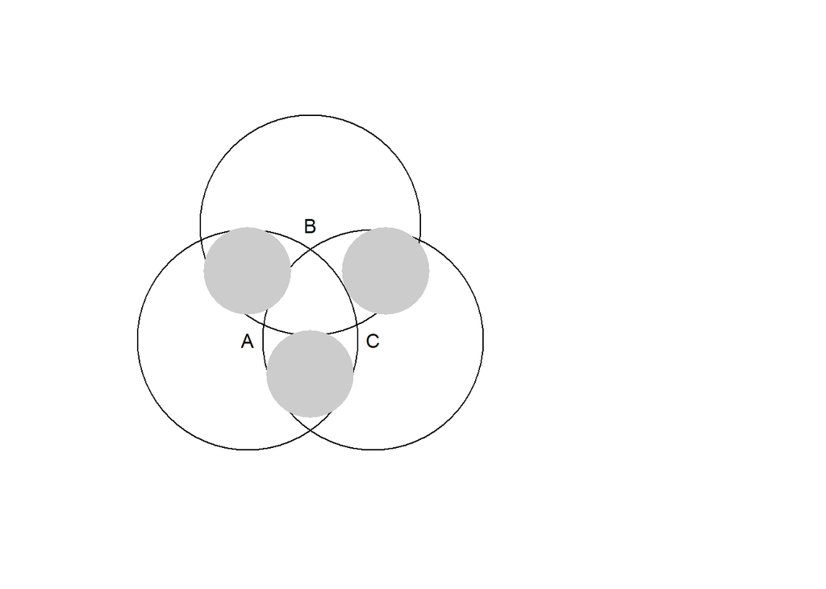

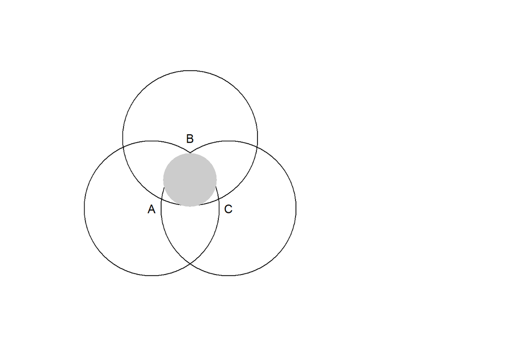

*Figure 1.13.3: P(A and B and C)*

### 1.14 Intersecting Probabilities

If two or more events intersect the probability associated with that intersection is the probabilities of the individual events.

P(A an B) = P(A) * P(B)

P(A an B and C) = P(A) * P(B) * P(C)

### 1.15 Conditional Probability

Probability of one event with the stipulation that another event also occurs.

Ex. Probability of selecting a “queen” given that the card is a “spade”

- We know we have a spade

P(Event A, given event B) = P(A and B, jointly)/P(B)

P(queen | spade) = P(queen of spades) / P(spade)

P(queen | spade) = frequency of queen of spades/frequency of spades

Note that this conditional probability is quite different from the probability of selecting a spade, given that the card is a queen.